# Red wine quality EDA by Alfred Wong

# Introduction

In this study we explore a dataset about wine quality created by Cortez et al. (2009) in:

P. Cortez, A. Cerdeira, F. Almeida, T. Matos and J. Reis. Modeling wine preferences by data mining from physicochemical properties. In Decision Support Systems, Elsevier, 47(4):547-553. ISSN: 0167-9236.

Available at:

[@Elsevier] http://dx.doi.org/10.1016/j.dss.2009.05.016

[Pre-press (pdf)] http://www3.dsi.uminho.pt/pcortez/winequality09.pdf

[bib] http://www3.dsi.uminho.pt/pcortez/dss09.bib

It has with 1599 observations of 12 variables.

Each observation is a bottle of the Portuguese “Vinho Verde” red wine. Our main feature here is the quality of the bottle, which is the median of integer (0-10) ratings given by at least three experts.

The rest of the features are measurements given by physiochemical tests. (The variable *X* shown below is just the index)

Our aim is to explore the data, paving the way for further studies to find out what features can help predict that a wine will be good.

```
## Classes 'tbl_df', 'tbl' and 'data.frame':    1599 obs. of  13 variables:
##  $ X                   : int  1 2 3 4 5 6 7 8 9 10 ...
##  $ fixed.acidity       : num  7.4 7.8 7.8 11.2 7.4 7.4 7.9 7.3 7.8 7.5 ...
##  $ volatile.acidity    : num  0.7 0.88 0.76 0.28 0.7 0.66 0.6 0.65 0.58 0.5 ...
##  $ citric.acid         : num  0 0 0.04 0.56 0 0 0.06 0 0.02 0.36 ...
##  $ residual.sugar      : num  1.9 2.6 2.3 1.9 1.9 1.8 1.6 1.2 2 6.1 ...
##  $ chlorides           : num  0.076 0.098 0.092 0.075 0.076 0.075 0.069 0.065 0.073 0.071 ...
##  $ free.sulfur.dioxide : num  11 25 15 17 11 13 15 15 9 17 ...
##  $ total.sulfur.dioxide: num  34 67 54 60 34 40 59 21 18 102 ...
##  $ density             : num  0.998 0.997 0.997 0.998 0.998 ...
##  $ pH                  : num  3.51 3.2 3.26 3.16 3.51 3.51 3.3 3.39 3.36 3.35 ...
##  $ sulphates           : num  0.56 0.68 0.65 0.58 0.56 0.56 0.46 0.47 0.57 0.8 ...
##  $ alcohol             : num  9.4 9.8 9.8 9.8 9.4 9.4 9.4 10 9.5 10.5 ...
##  $ quality             : int  5 5 5 6 5 5 5 7 7 5 ...
```

```
##        X          fixed.acidity   volatile.acidity  citric.acid
##  Min.   :   1.0   Min.   : 4.60   Min.   :0.1200   Min.   :0.000
##  1st Qu.: 400.5   1st Qu.: 7.10   1st Qu.:0.3900   1st Qu.:0.090
##  Median : 800.0   Median : 7.90   Median :0.5200   Median :0.260
##  Mean   : 800.0   Mean   : 8.32   Mean   :0.5278   Mean   :0.271
##  3rd Qu.:1199.5   3rd Qu.: 9.20   3rd Qu.:0.6400   3rd Qu.:0.420
##  Max.   :1599.0   Max.   :15.90   Max.   :1.5800   Max.   :1.000
##  residual.sugar     chlorides       free.sulfur.dioxide
##  Min.   : 0.900   Min.   :0.01200   Min.   : 1.00
##  1st Qu.: 1.900   1st Qu.:0.07000   1st Qu.: 7.00
##  Median : 2.200   Median :0.07900   Median :14.00
##  Mean   : 2.539   Mean   :0.08747   Mean   :15.87
##  3rd Qu.: 2.600   3rd Qu.:0.09000   3rd Qu.:21.00
##  Max.   :15.500   Max.   :0.61100   Max.   :72.00
##  total.sulfur.dioxide    density             pH          sulphates
##  Min.   :  6.00       Min.   :0.9901   Min.   :2.740   Min.   :0.3300
##  1st Qu.: 22.00       1st Qu.:0.9956   1st Qu.:3.210   1st Qu.:0.5500
##  Median : 38.00       Median :0.9968   Median :3.310   Median :0.6200
##  Mean   : 46.47       Mean   :0.9967   Mean   :3.311   Mean   :0.6581
##  3rd Qu.: 62.00       3rd Qu.:0.9978   3rd Qu.:3.400   3rd Qu.:0.7300
##  Max.   :289.00       Max.   :1.0037   Max.   :4.010   Max.   :2.0000
##     alcohol         quality
##  Min.   : 8.40   Min.   :3.000
##  1st Qu.: 9.50   1st Qu.:5.000
##  Median :10.20   Median :6.000
##  Mean   :10.42   Mean   :5.636
##  3rd Qu.:11.10   3rd Qu.:6.000
##  Max.   :14.90   Max.   :8.000
```

Here is the overview of the data.

```
##              quality              alcohol        fixed.acidity
##                    0                    0                    0
##     volatile.acidity          citric.acid                   pH
##                    0                    0                    0
##       residual.sugar            chlorides  free.sulfur.dioxide
##                    0                    0                    0
## total.sulfur.dioxide            sulphates              density
##                    0                    0                    0
```

We don’t have any NA values.

# Univariate Plots Section

Now let’s take a look at the variables one by one.

### *quality*

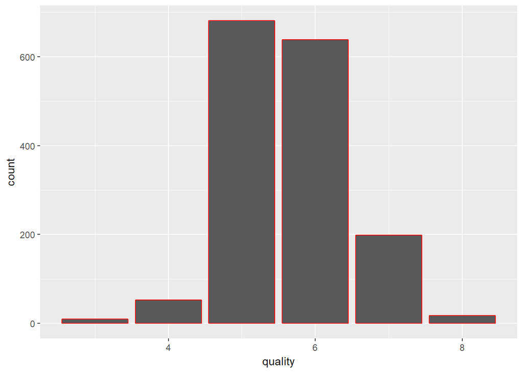

*quality* is the rating of the wine. 3 or more experts rated the wine from 0, the worst, to 10, the best, and the median is taken. All of the values we have are between 3 and 8, and mostly concentrated in 5 and 6. This will be the focus of our study, as our aim is to explore the variables affecting *quality*.

### *alcohol*

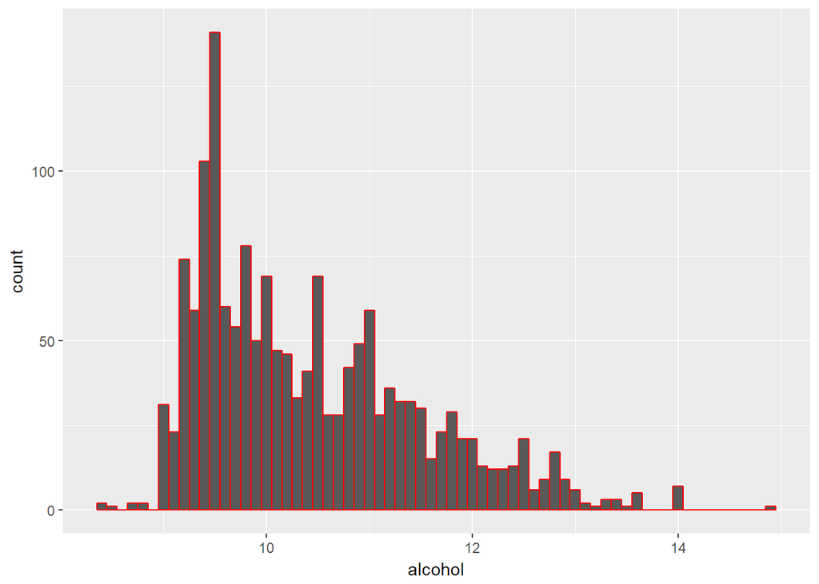

*alcohol* is the alcohol content by volume. We see that most of our wines have values between 9 and 14, with a mean of 10.42 and a median of 10.20.

### *fixed.acidity*

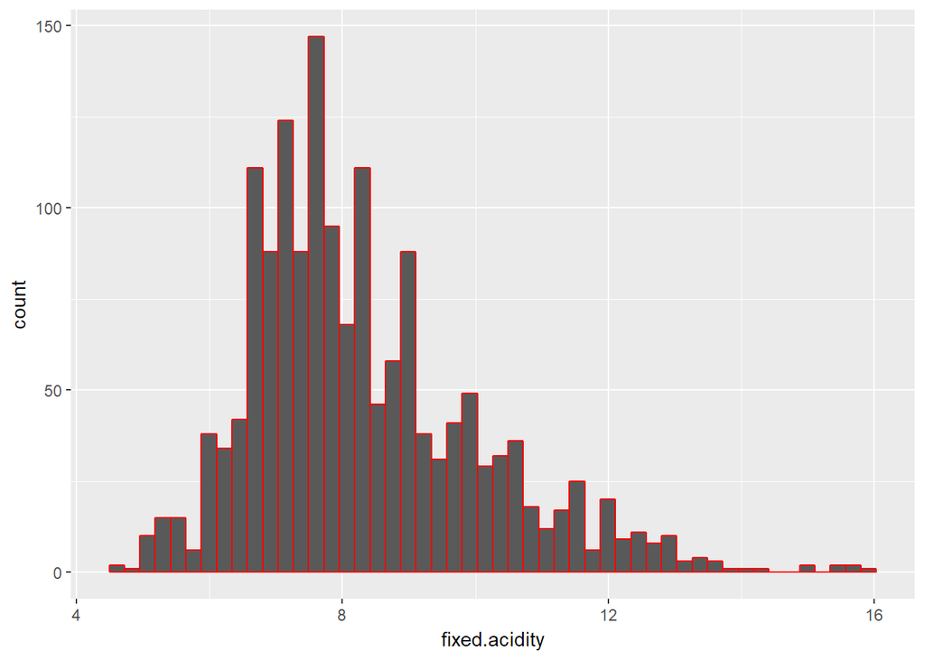

*fixed.acidity* is the amount of tartaric acid present in the wine. Most wines in our data set have around 8 gram per liter. The distribution have a bit of skewedness towards the right.

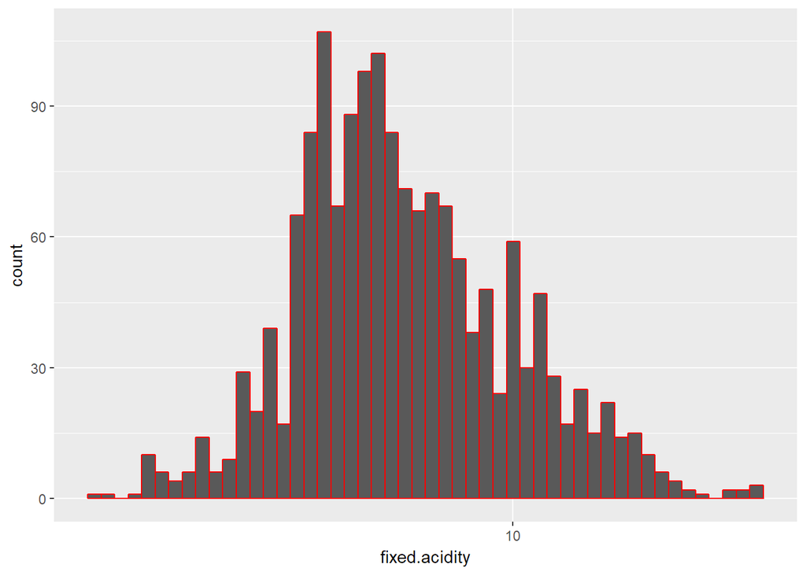

With the log transformation the distribution looks somewhat closer to normal.

### *volatile.acidity*

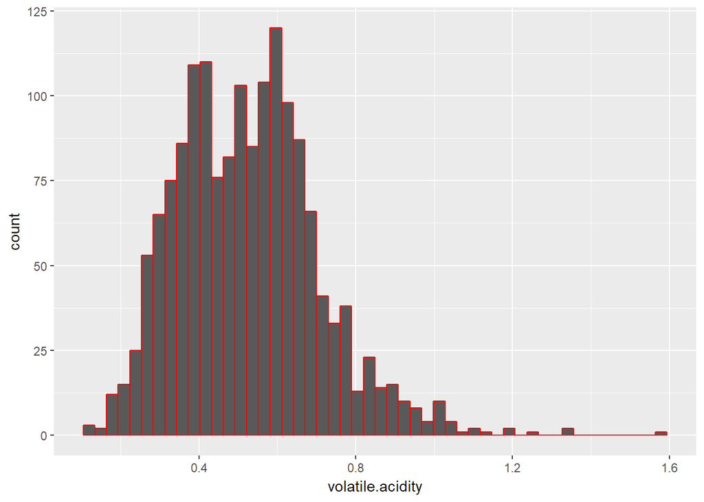

*volatile.acidity* is the amount of acetic acid, in grams / liter. Usually it is associated with bad quality with its vinegar-y smell. The distribution looks bimodal, with peaks at around 0.4 and 0.6 g/L

### *citric.acid*

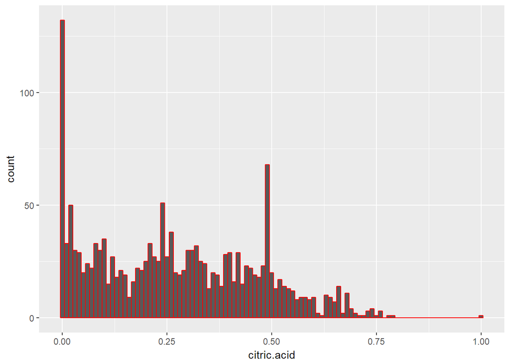

*citric.acid* is the amount of citric acid in the wine, again in grams / liter. Many of the wines in our dataset has none at all. There are a few spots of concentrated frequencies at 0.49, 0.24 and 0.02. This is not a binning problem in our plot, as I have matched the binwidth with the data.

As for the other values, we have a few outliers at 1.00, and the rest are somewhat uniformly distributed up to around 0.5, and then gradually decrease.

### *pH*

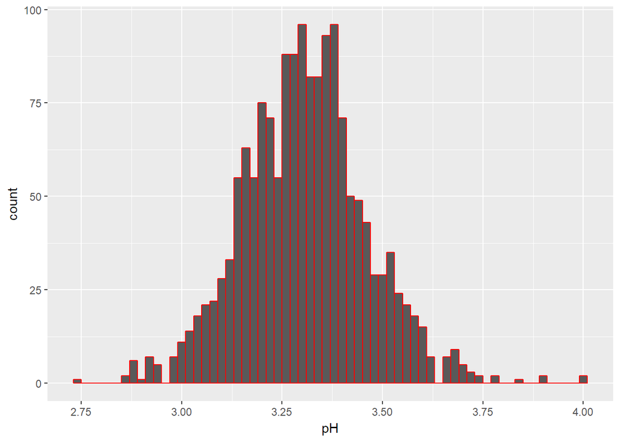

The pH value of the wine. The lower the value the more acidic is the wine.

The distribution is symmetric with a mean of 3.311.

Note that pH value itself is a logarithmic measurement of hydrogen ions, so at least chemically speaking, a wine with a pH value of 3 is ten times more acidic than one with a 4.

However, pH value is not exactly the log of (*fixed.acidity* + *volatile.acidity*), as the pH value is affected by both the amount and strength of acids present, while the acidity values count only the amount of the acids concerned.

### *residual.sugar*

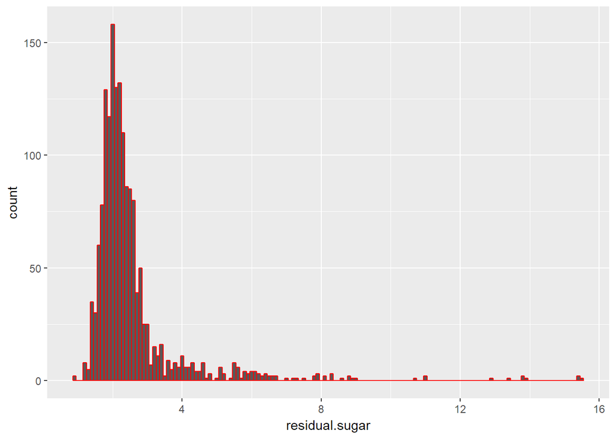

*residual.sugar* is the amount of sugar, in gram / liter, left in the wine after the fermentation process ends, or stopped by the winemaker.

Ceteris paribus, the more residual sugar there is, the sweeter the wine should taste. But then the sensation of sweetness is also affected by many other factors, such as acidity.

The majority of observations form a bell shape, with the rest forming a long tail to the right. The median is 2.2 while the mean is 2.54.

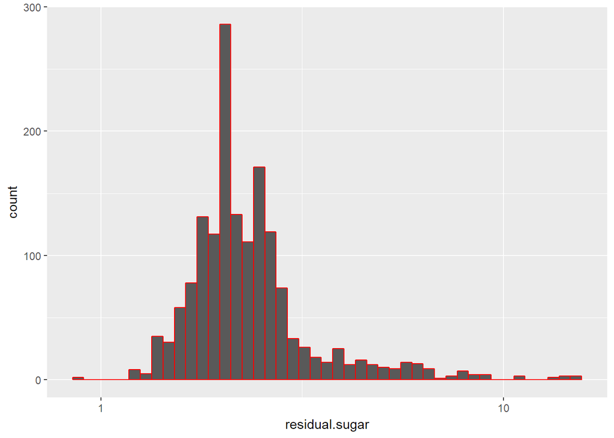

Again with a log scale the distribution looks more symmetric.

### *chlorides*

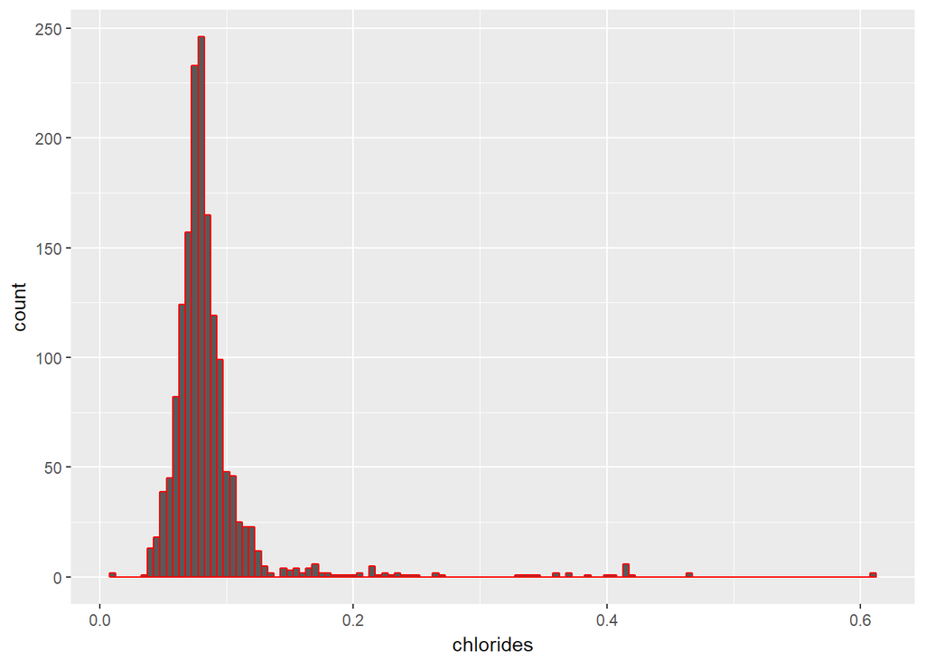

*cholorides* is the amount of sodium chlorides (ie, salt) in the wine, in gram / liter. In large enough amounts they give the wine a salty taste. Most of the wines in our sample have less than 0.12 g/L, but some outliers have up to 0.6 g/L.

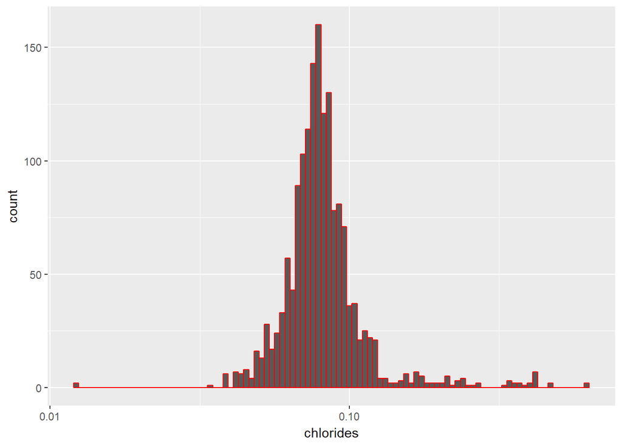

Here the log transformation makes the main part of the distribution less bell-like, but evens out the tails on both sides a little.

### *free.sulfur.dioxide*

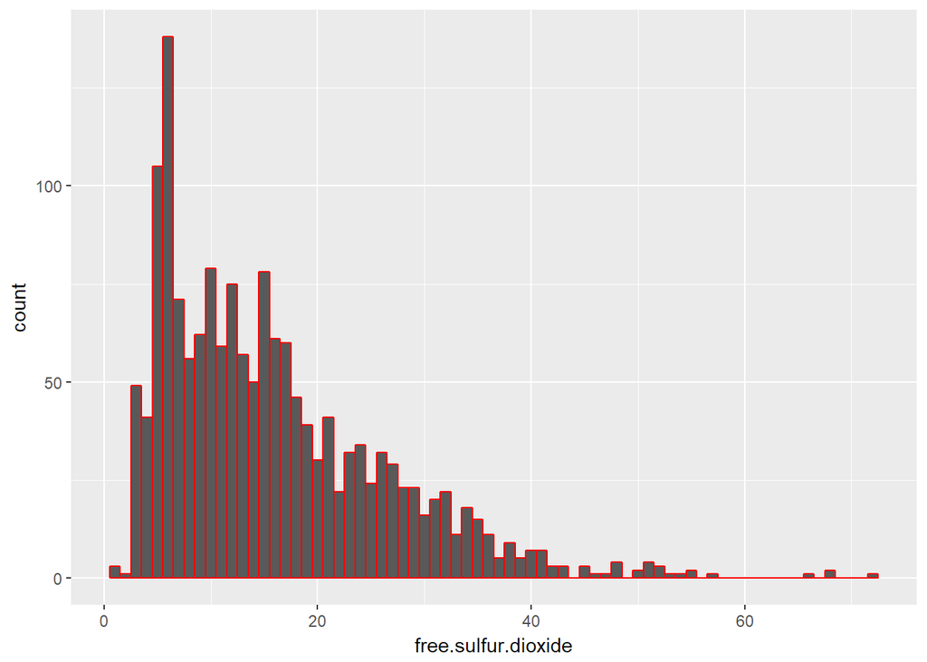

Sulfur dioxide is a by-product of the fermentation process, but is also added to the wine by the winemaker. It serves as 1. a anti-microbial agent that suppresses harmful yeast and bacteria growth, and 2. an anti-oxidatant to keep the wine fresh.

*free.sulfur.dioxide* is the amount that exists as molecular SO2, sulfite or bisulfite ions, that helps suppress microbes and oxidation. The unit is mg / liter.

The distribution of *free.sulphur.dioxide* has a tail to the right. But neither the logarithic or the square root transformation would make it very bell-shaped.

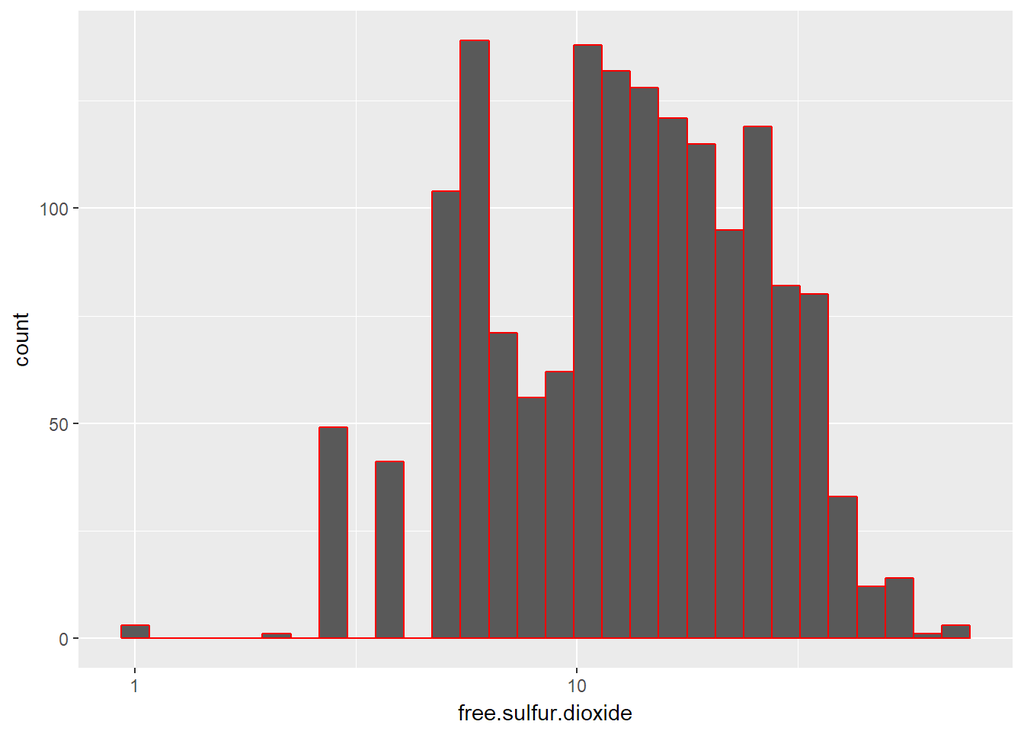

Like in this log-transformed plot.

### *total.sulfur.dioxide*

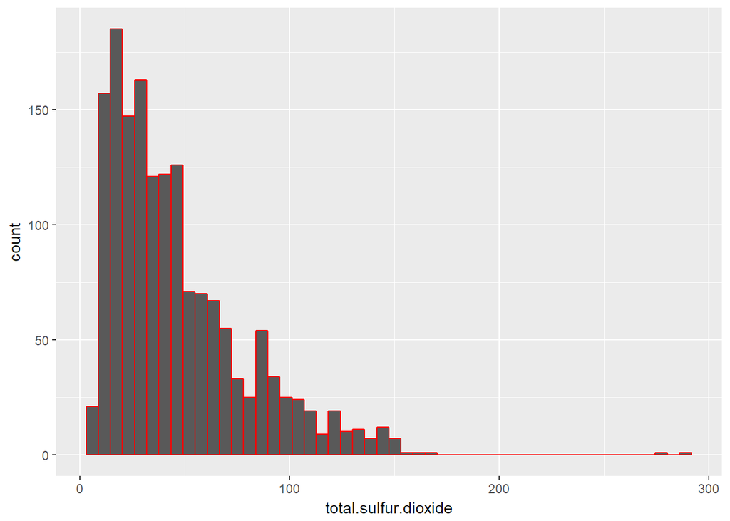

Bound sulfur dioxide is the portion that is already attached to other compounds in the wine, and thus does not work as antimicrobial or antioxidant.

*total.sulfur.dioxie* is the total of free plus bound sulfur dioxide.

The distribution skews to the right, with a mean of 46.47 and a median of 38.

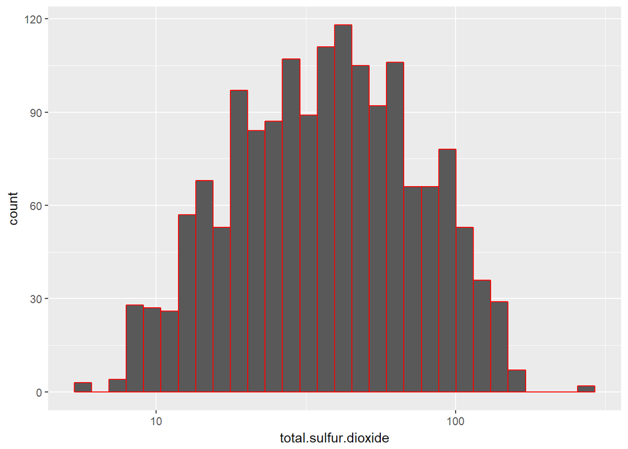

A log transformation makes it much more symmetric.

### *sulphates*

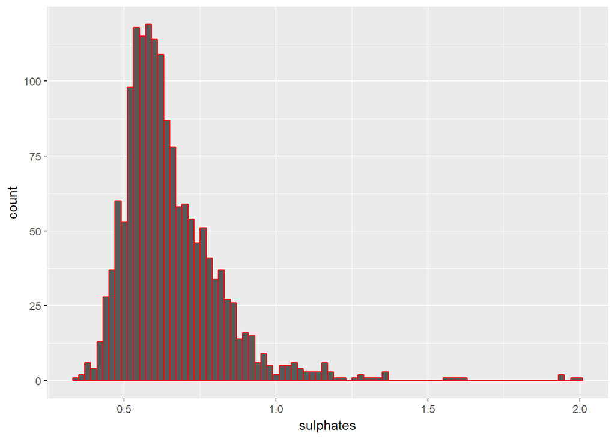

*sulphates* is the amount of potassium sulphate in the wine, in gram / liter. It is an additive to increase the sulfur dioxide levels.

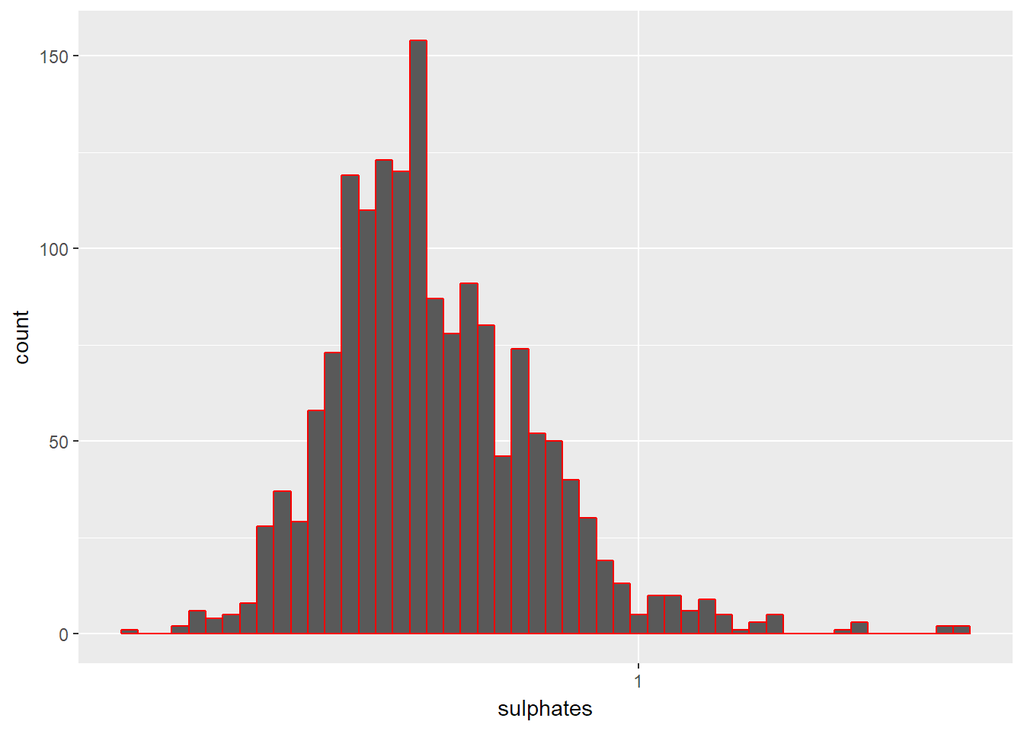

Again the logarithmic transformation makes the distribution more symmetric.

### *density*

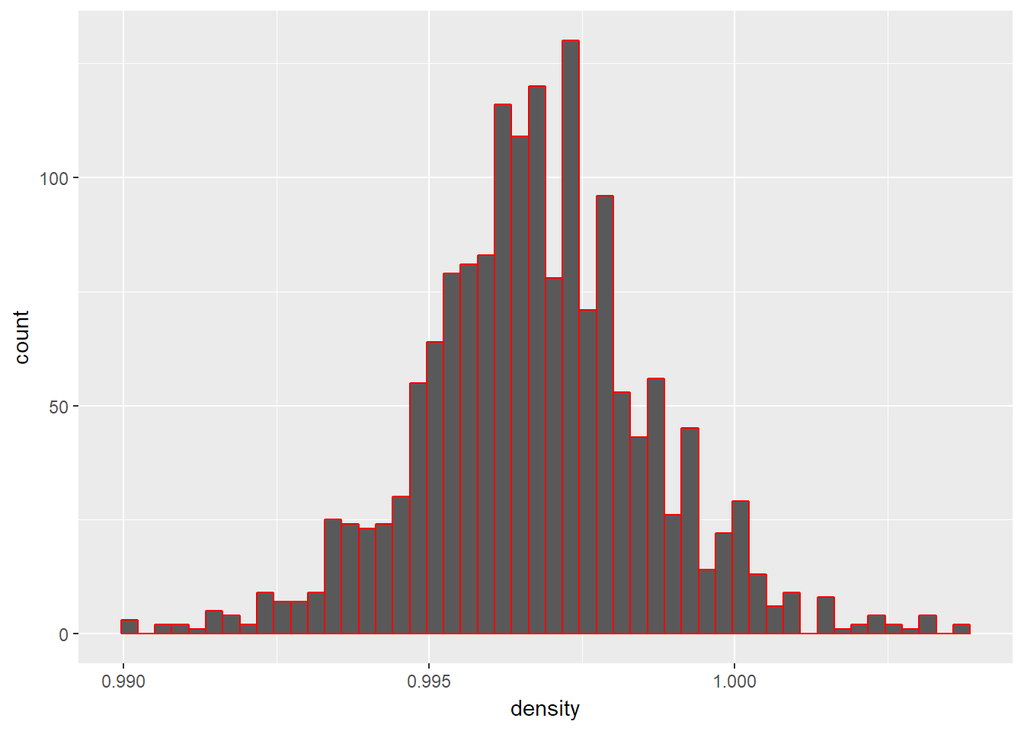

*density* is the density of the wine, in gram / ml.

The distribution looks quite normal, with the mean and median at 0.9967 and 0.9968 respectively.

Most of the wines have a density < 1, ie, lighter than water.

# Univariate Analysis

The data set contains 1599 observations of 12 variables. One of them is *quality*, the focus of our study.

Given how few variables there are, we’ll use all the other variables in our study, in hopes to find relationship with quality.

I have created the logarithmic transformations of *fixed.acidity*, *residual.sugar*, *chlorides*, *total.sulfur.dioxide* and *sulphates* for future use.

A *bound.sulfur.dioxide.log10* is created by taking the logarithm of the difference between *total.sulfur.dioxide* and *free.sulfur.dioxide*.

I’ve also binned *quality* into 3 categories, “bad” for *quality* 3 and 4, “average” for 5 and 6, “good” for 7 and 8. This will be used in multivariate analyses to reduce the number of colors used for better contrast.

# Bivariate Plots Section

### Pair plots

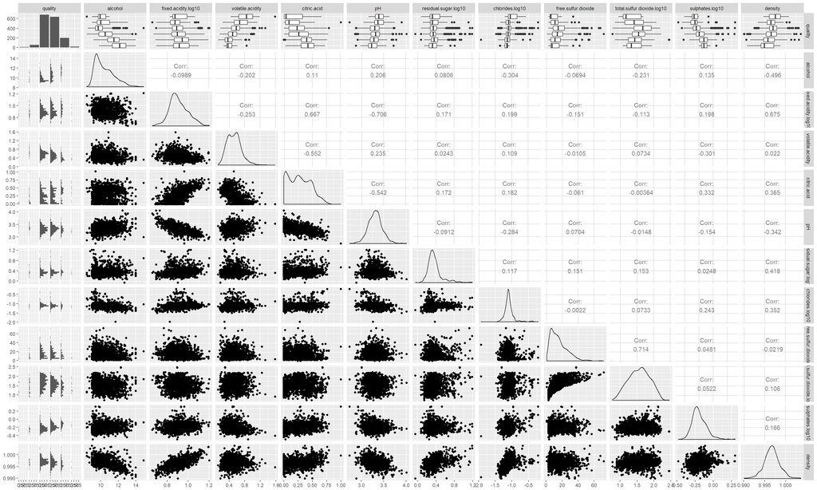

Let’s first take a glance over the paired plots. From the box plots with *quality*, we can see that *alcohol*, *volatile.acidity*, *citric.acid* seem to show the strongest relationship with *quality*.

We’ll explore these pairs, as well as other pairs with high correlation one by one. The number below the plots between *quality* and other features are the Spearman’s correlation coefficient, using *quality* as an ordinal factor.

### *alcohol* and *quality*

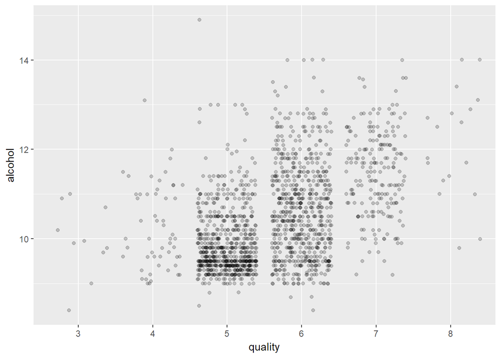

```
## [1] 0.4785317
```

We can see quite an obvious positive relationship between *alcohol* and *quality*.

The spearman’s correlation coefficient, at 0.48, is coherent with the observation.

Of course, this isn’t to say that higher alcohol content necessarily makes the wine better, otherwise even the worst ports and sherries would trump the best wines.

Rather, it could be that better made wines happen to have higher alcohol content, due to a third factor.

### *volatile.acidity* and *quality*

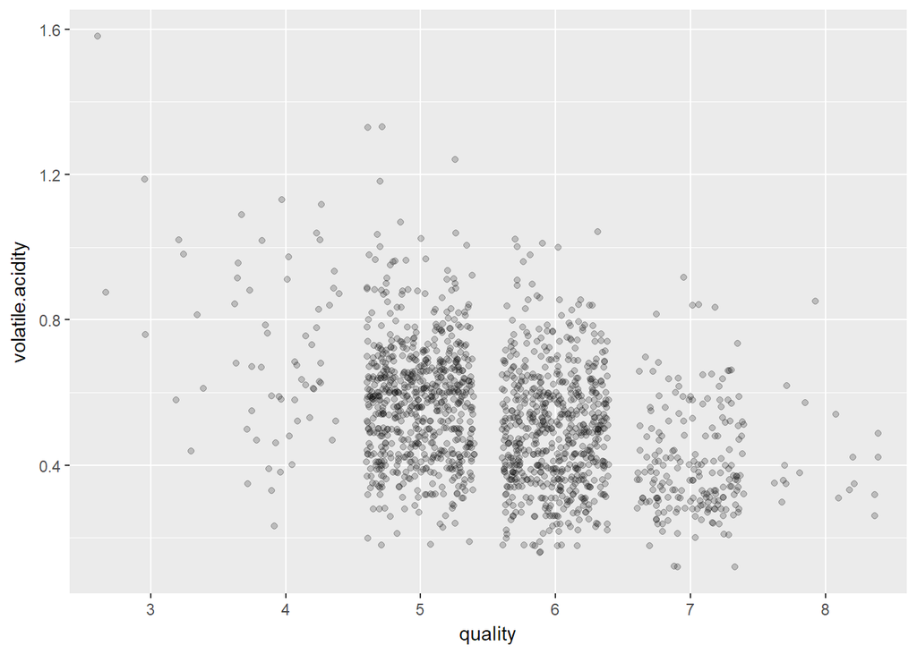

```
## [1] -0.3806465
```

Unsurprisingly, *volatile.acidity* shows a negative correlation with *quality*, at -0.38.

Acetic acid, with its vinegar-y smell, is quite universally agreed upon as unpleasant in wine.

### *citric.acid* and *quality*

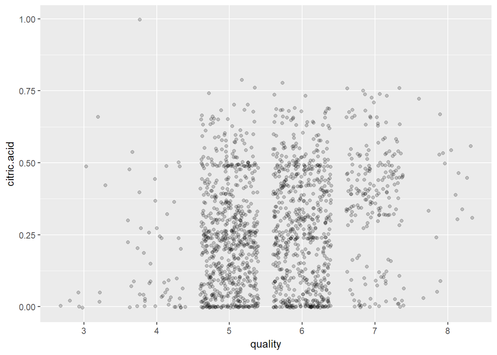

```
## [1] 0.2134809
```

The relationship betwen *citric.acid* and *quality* is less clear. The coefficient is 0.21.

### *chlorides.log10* and *quality*

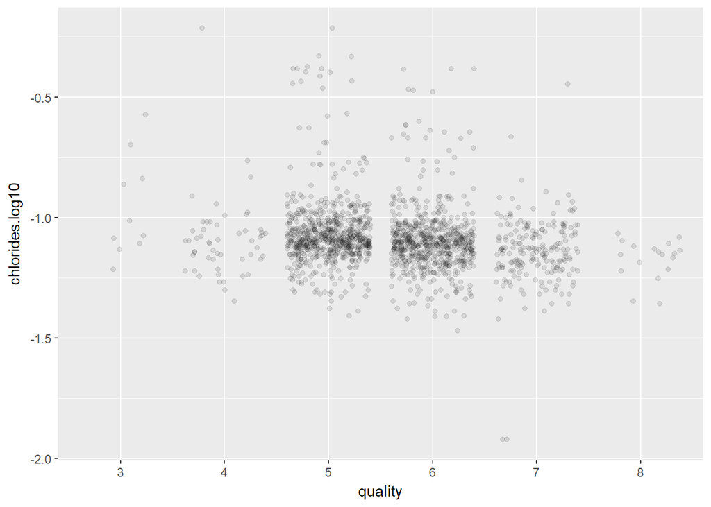

```
## [1] -0.1899223
```

### Sulphur dioxides and *quality*

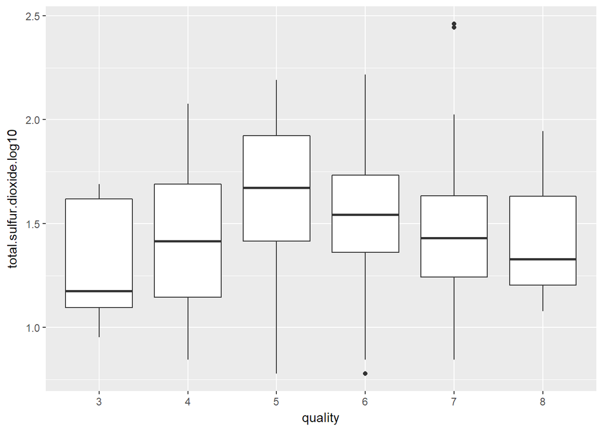

```
## [1] -0.1967351
```

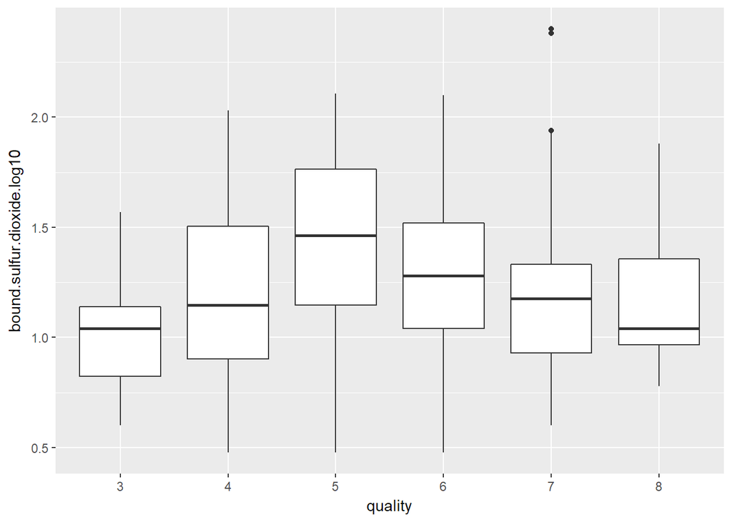

```
## [1] -0.2333584
```

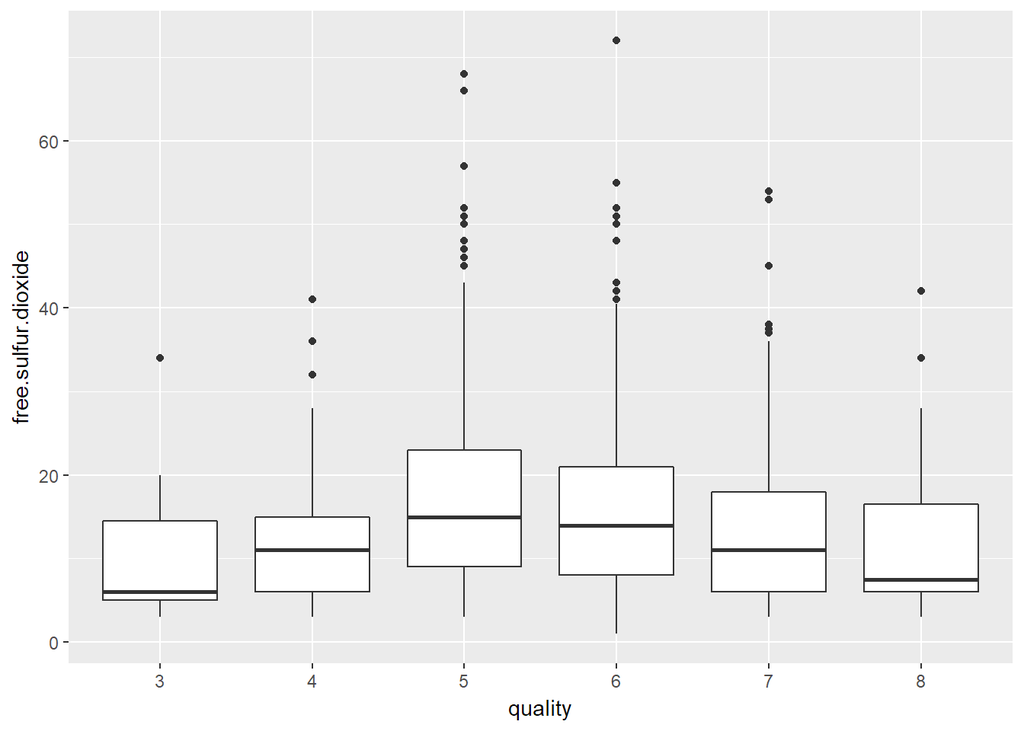

```
## [1] -0.05690065
```

But all of them seem to show a parabolic relationship with *quality*, if the latter is to be interpreted as a continuous variable.

This may warrant further investigation, or some feature engineering.

### *sulphates* and *quality*

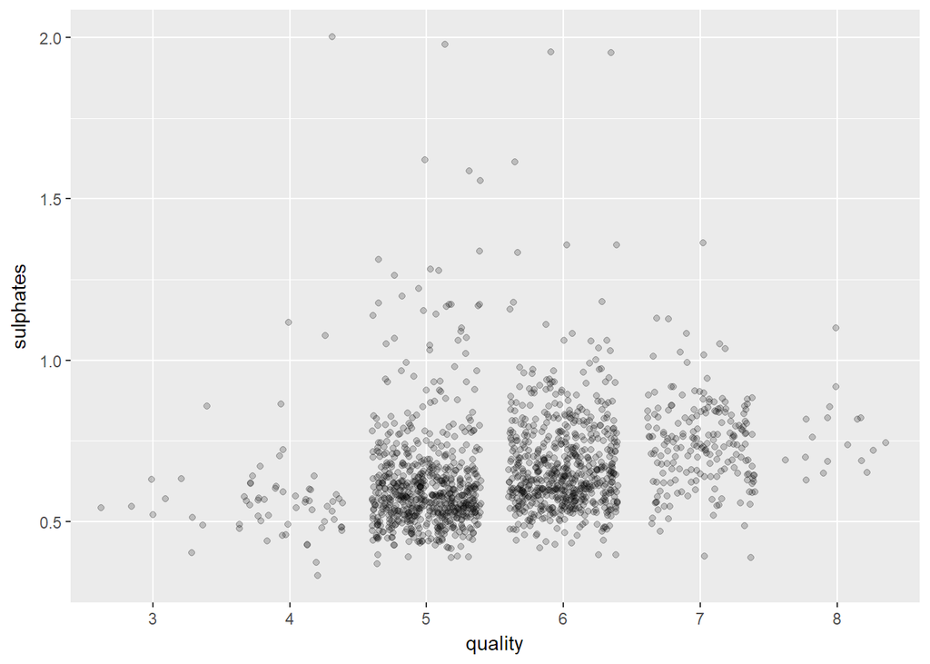

```
## [1] 0.3770602
```

With *sulphates* we see quite a clear positive relationship with quality, with spearman’s coefficient at 0.38.

### *density* and *quality*

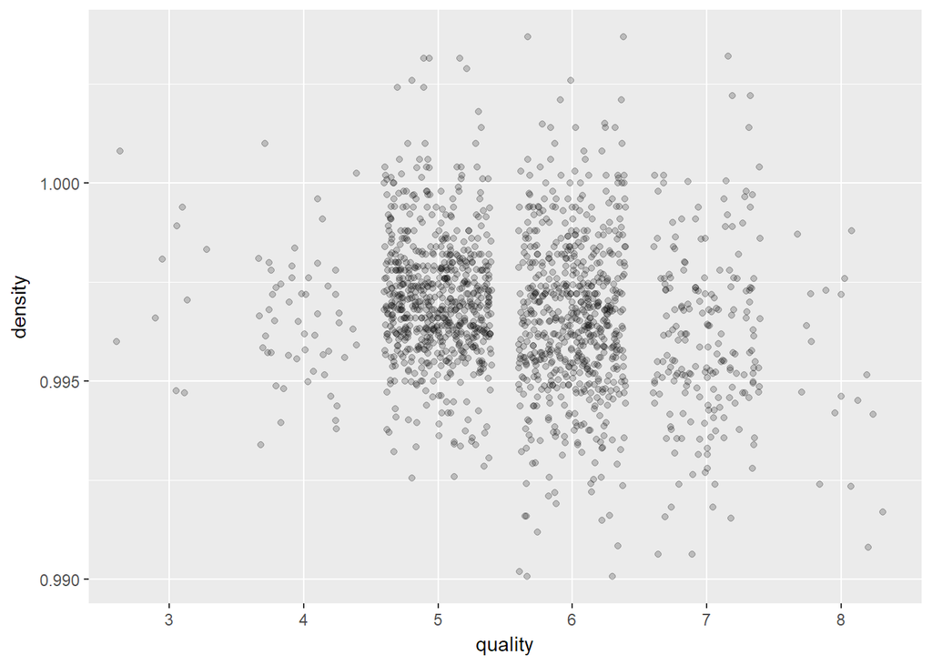

```
## [1] -0.1770741
```

The relationship between *density* and *quality* is quite weak.

Also, *density* is highly correlated to many other variables we have, which, in turn, are correlated to *quality*. It is doubtful if *density* is still meaningful if those other variables are accounted for.

### *citric.acid* and *fixed.acidity*

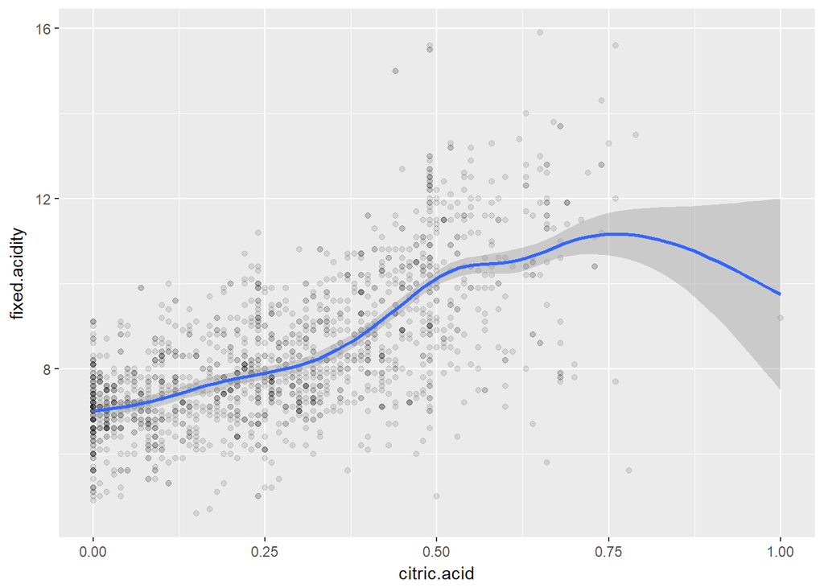

This is one of the strongly correlated pairs among all the variables we have.

### *fixed.acidity.log10* and *pH*

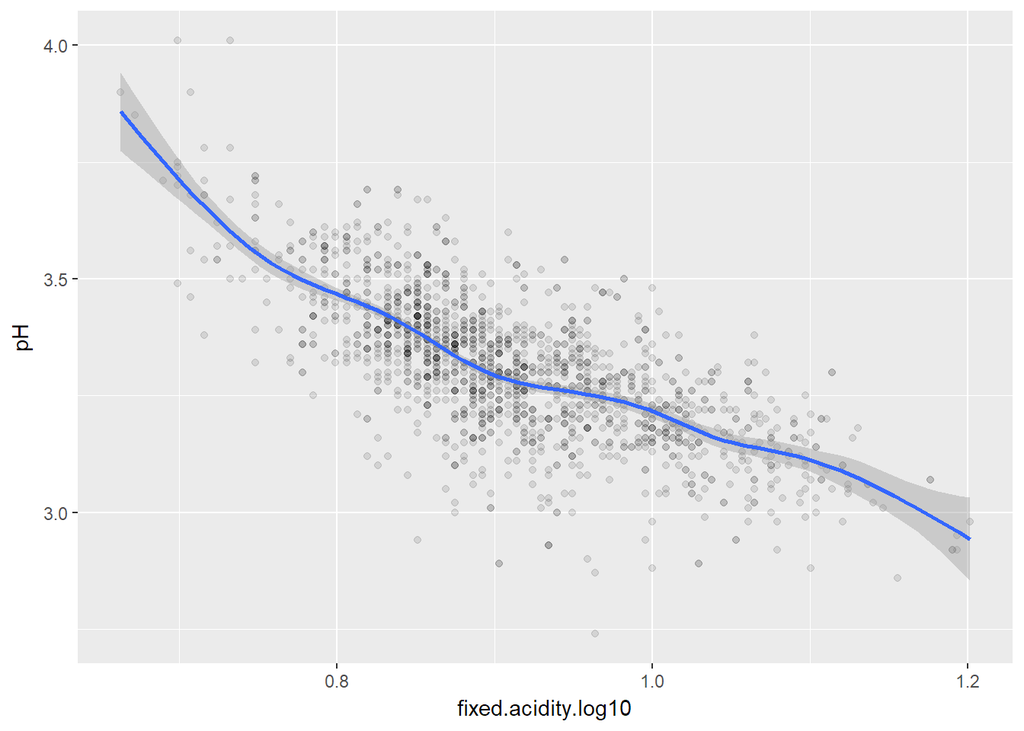

As one would expect, *fixed.acidity* has a strong negative correlation with *pH*.

### *volatile.acidity* and *pH*

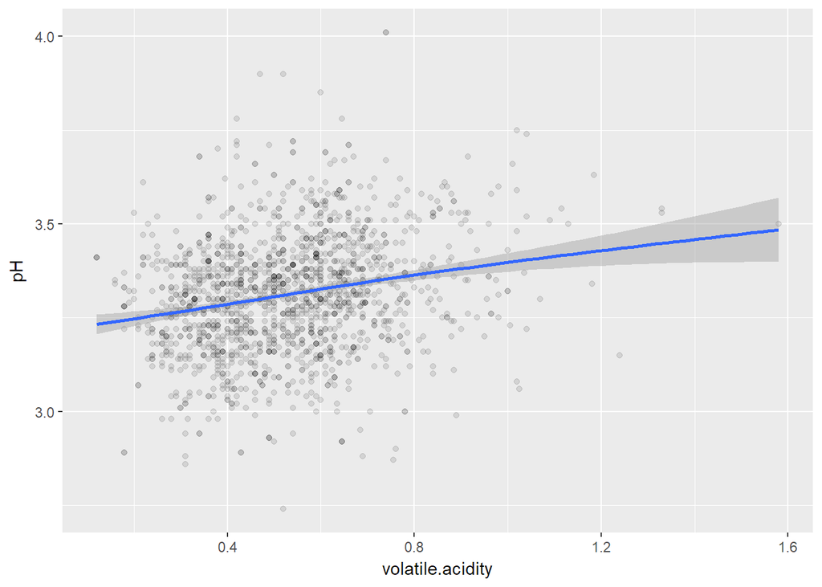

A little surprising is that *volatile.acidity* is slightly positively correlated with *pH*, at 0.235.

### *alcohol* and *density*

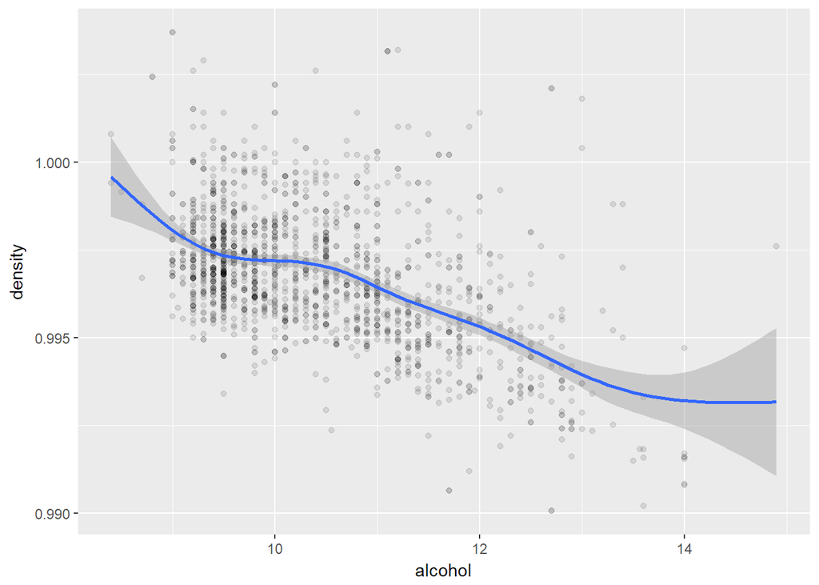

*Density* is correlated with many of our variables, one of which is *alcohol*. The negative correlation makes sense, as alcohol is less dense than water.